# Homework 2

```r
install.packages("gapminder")
```

1. Examine the organization of the data set. Using the code discussed in class, randomly sample one country. Show the code used to sample. Set seed so that I could reproduce your code.

```r
library(dplyr)
set.seed(5098765)
randomcountry <- sample_n(gapminder, 1)
randomcountry
```

[output not shown]

2. For the country that was sampled, describe the dynamics of its population, life expectancy, and GDP per capita from the earliest to the latest year available.
- Life expectancy, GDP per capita, and the population of Denmark gradually increased through the years.

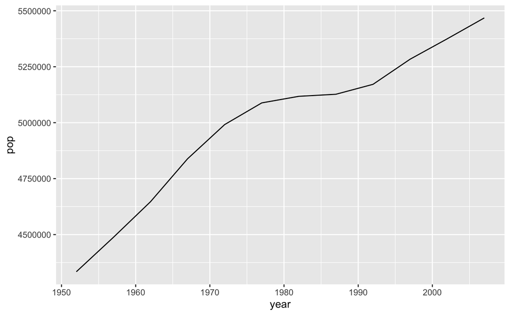

```r
Denmark <- gapminder %>%
filter(country == "Denmark")
 Denmark %>%  ggplot(aes(x = year, y = pop)) + geom_line()
```

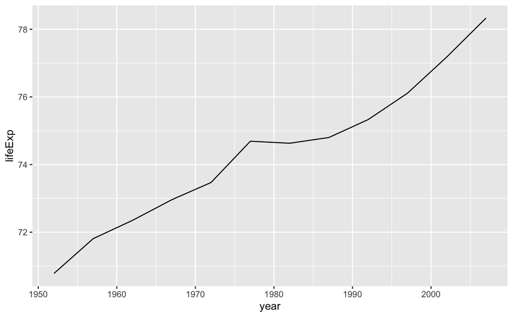

```r
 Denmark %>%  ggplot(aes(x=year, y=lifeExp)) + geom_line()
```

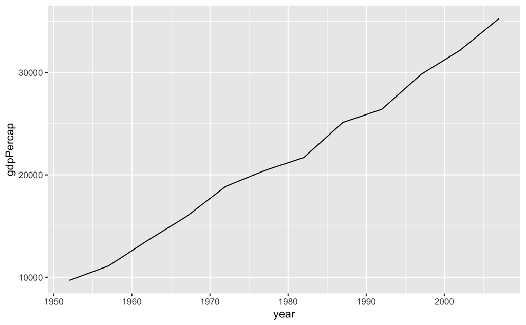

```r
 Denmark %>%  ggplot(aes(x=year, y=gdpPercap)) + geom_line()
```

3. How does the population, life expectancy, and GDP per capita compare with the averages for the continent and for the world as a whole in the earliest year of observation and the latest year of observation. (You will need to calculate corresponding means for this)

```r
#Mean Europe 1952
gapminder %>%
  filter(continent=="Europe", year == min(year)) %>%
  summarise(avg_pop=mean(pop), avg_lifeExp=mean(lifeExp), avg_gdpPCap= mean(gdpPercap))
```

| avg_pop | avg_lifeExp | avg_gdpPCap |
| --- | --- | --- |
| 13937362 | 64 | 5661 |

```r
#Mean World 1952
gapminder %>%
  filter(year == min(year)) %>%
  summarise(avg_pop=mean(pop), avg_lifeExp=mean(lifeExp), avg_gdpPCap= mean(gdpPercap))
```

| avg_pop | avg_lifeExp | avg_gdpPCap |
| --- | --- | --- |
| 16950402 | 49 | 3725 |

```r
#Mean Europe 2007
gapminder %>%
  filter(continent=="Europe", year == max(year)) %>%
  summarise(avg_pop=mean(pop), avg_lifeExp=mean(lifeExp), avg_gdpPCap= mean(gdpPercap))
```

| avg_pop | avg_lifeExp | avg_gdpPCap |
| --- | --- | --- |
| 19536618 | 78 | 25054 |

```r
#Mean World 2007
gapminder %>%
  filter(year == max(year)) %>%
  summarise(avg_pop=mean(pop), avg_lifeExp=mean(lifeExp), avg_gdpPCap= mean(gdpPercap))
```

| avg_pop | avg_lifeExp | avg_gdpPCap |
| --- | --- | --- |
| 44021220 | 67 | 11680 |

```r
#For purposes of answering question 9:
#Mean Denmark 1952
gapminder %>%
  filter(country=="Denmark", year == min(year)) %>%
  summarise(avg_pop=mean(pop), avg_lifeExp=mean(lifeExp), avg_gdpPCap= mean(gdpPercap))
```

| avg_pop | avg_lifeExp | avg_gdpPCap |
| --- | --- | --- |
| 4334000 | 71 | 9692 |

```r
#Mean Denmark 2007
gapminder %>%
  filter(country=="Denmark", year == max(year)) %>%
  summarise(avg_pop=mean(pop), avg_lifeExp=mean(lifeExp), avg_gdpPCap= mean(gdpPercap))
```

| avg_pop | avg_lifeExp | avg_gdpPCap |
| --- | --- | --- |
| 5468120 | 78 | 35278 |

4. Calculate the standard deviation for the continent and for the world for each indicator for the first and last year of observations. How many standard deviations away from the mean was your country in the first year of observation? In the last year of observation? What does it say about the development of your country?

```r
#For Denmark (World) population
zscoreWorld<-gapminder%>%
  group_by(year) %>%
  mutate(avgpop=mean(pop), sdpop=sd(pop))%>%
  filter (country == "Denmark") %>%
  mutate(zscore=(pop-avgpop)/sdpop) %>%
  filter(year==min(year))
zscoreWorld
```

| country | continent | year | lifeExp | pop | gdpPercap | avgpop | sdpop | zscore |
| --- | --- | --- | --- | --- | --- | --- | --- | --- |
| Denmark | Europe | 1952 | 71 | 4334000 | 9692 | 16950402 | 58100863 | -0.22 |
| Denmark | Europe | 1957 | 72 | 4487831 | 11100 | 18763413 | 65504285 | -0.22 |
| Denmark | Europe | 1962 | 72 | 4646899 | 13583 | 20421007 | 69788650 | -0.23 |
| Denmark | Europe | 1967 | 73 | 4838800 | 15937 | 22658298 | 78375481 | -0.23 |
| Denmark | Europe | 1972 | 73 | 4991596 | 18866 | 25189980 | 88646817 | -0.23 |
| Denmark | Europe | 1977 | 75 | 5088419 | 20423 | 27676379 | 97481091 | -0.23 |
| Denmark | Europe | 1982 | 75 | 5117810 | 21688 | 30207302 | 105098650 | -0.24 |
| Denmark | Europe | 1987 | 75 | 5127024 | 25116 | 33038573 | 114756180 | -0.24 |
| Denmark | Europe | 1992 | 75 | 5171393 | 26407 | 35990917 | 124502589 | -0.25 |
| Denmark | Europe | 1997 | 76 | 5283663 | 29804 | 38839468 | 133417391 | -0.25 |

[output cut: 2 more lines]

```r
#For Denmark (Continent) population
zscoreContinent<-gapminder%>%
  group_by(year) %>%
  filter (continent == "Europe") %>%
  mutate(avgpop=mean(pop),sdpop=sd(pop))%>%
  filter (country == "Denmark") %>%
  mutate(zscore=(pop-avgpop)/sdpop) %>%
  filter(year==min(year))
zscoreContinent
```

| country | continent | year | lifeExp | pop | gdpPercap | avgpop | sdpop | zscore |
| --- | --- | --- | --- | --- | --- | --- | --- | --- |
| Denmark | Europe | 1952 | 71 | 4334000 | 9692 | 13937362 | 17247450 | -0.56 |
| Denmark | Europe | 1957 | 72 | 4487831 | 11100 | 14596345 | 17832354 | -0.57 |
| Denmark | Europe | 1962 | 72 | 4646899 | 13583 | 15345172 | 18656418 | -0.57 |
| Denmark | Europe | 1967 | 73 | 4838800 | 15937 | 16039299 | 19443589 | -0.58 |
| Denmark | Europe | 1972 | 73 | 4991596 | 18866 | 16687835 | 20180340 | -0.58 |
| Denmark | Europe | 1977 | 75 | 5088419 | 20423 | 17238818 | 20560544 | -0.59 |
| Denmark | Europe | 1982 | 75 | 5117810 | 21688 | 17708897 | 20971293 | -0.60 |
| Denmark | Europe | 1987 | 75 | 5127024 | 25116 | 18103139 | 21369711 | -0.61 |
| Denmark | Europe | 1992 | 75 | 5171393 | 26407 | 18604760 | 22126736 | -0.61 |
| Denmark | Europe | 1997 | 76 | 5283663 | 29804 | 18964805 | 22748145 | -0.60 |

[output cut: 2 more lines]

```r
#For Denmark (World) Life Expectancy (Is it correct, like the previous ones??)
zscoreWorldLifeExp<-gapminder%>%
  group_by(year) %>%
  mutate(avglifeExp=mean(lifeExp), sdlifeExp=sd(lifeExp))%>%
  filter (country == "Denmark") %>%
  mutate(zscore=(lifeExp-avglifeExp)/sdlifeExp) %>%
  filter(year==min(year))
zscoreWorldLifeExp
```

| country | continent | year | lifeExp | pop | gdpPercap | avglifeExp | sdlifeExp | zscore |
| --- | --- | --- | --- | --- | --- | --- | --- | --- |
| Denmark | Europe | 1952 | 71 | 4334000 | 9692 | 49 | 12 | 1.78 |
| Denmark | Europe | 1957 | 72 | 4487831 | 11100 | 52 | 12 | 1.66 |
| Denmark | Europe | 1962 | 72 | 4646899 | 13583 | 54 | 12 | 1.55 |
| Denmark | Europe | 1967 | 73 | 4838800 | 15937 | 56 | 12 | 1.47 |
| Denmark | Europe | 1972 | 73 | 4991596 | 18866 | 58 | 11 | 1.39 |
| Denmark | Europe | 1977 | 75 | 5088419 | 20423 | 60 | 11 | 1.35 |
| Denmark | Europe | 1982 | 75 | 5117810 | 21688 | 62 | 11 | 1.22 |
| Denmark | Europe | 1987 | 75 | 5127024 | 25116 | 63 | 11 | 1.10 |
| Denmark | Europe | 1992 | 75 | 5171393 | 26407 | 64 | 11 | 0.99 |
| Denmark | Europe | 1997 | 76 | 5283663 | 29804 | 65 | 12 | 0.96 |

[output cut: 2 more lines]

```r
#For Denmark (Continent) Life Expectancy
zscoreContinentLifeExp<-gapminder%>%
  group_by(year) %>%
  filter (continent == "Europe") %>%
  mutate(avglifeExp=mean(lifeExp),sdlifeExp=sd(lifeExp))%>%
  filter (country == "Denmark") %>%
  mutate(zscore=(lifeExp-avglifeExp)/sdlifeExp) %>%
  filter(year==min(year))
zscoreContinentLifeExp
```

| country | continent | year | lifeExp | pop | gdpPercap | avglifeExp | sdlifeExp | zscore |
| --- | --- | --- | --- | --- | --- | --- | --- | --- |
| Denmark | Europe | 1952 | 71 | 4334000 | 9692 | 64 | 6.4 | 1.00 |
| Denmark | Europe | 1957 | 72 | 4487831 | 11100 | 67 | 5.3 | 0.96 |
| Denmark | Europe | 1962 | 72 | 4646899 | 13583 | 69 | 4.3 | 0.89 |
| Denmark | Europe | 1967 | 73 | 4838800 | 15937 | 70 | 3.8 | 0.85 |
| Denmark | Europe | 1972 | 73 | 4991596 | 18866 | 71 | 3.2 | 0.83 |
| Denmark | Europe | 1977 | 75 | 5088419 | 20423 | 72 | 3.1 | 0.88 |
| Denmark | Europe | 1982 | 75 | 5117810 | 21688 | 73 | 3.2 | 0.57 |
| Denmark | Europe | 1987 | 75 | 5127024 | 25116 | 74 | 3.2 | 0.37 |
| Denmark | Europe | 1992 | 75 | 5171393 | 26407 | 74 | 3.2 | 0.28 |
| Denmark | Europe | 1997 | 76 | 5283663 | 29804 | 76 | 3.1 | 0.19 |

[output cut: 2 more lines]

```r
#For Denmark (World) GDP per Capita
zscoreWorldAvGDPpCap<-gapminder%>%
  group_by(year) %>%
  mutate(avggdpPercap=mean(gdpPercap), sdgdpPercap=sd(gdpPercap))%>%
  filter (country == "Denmark") %>%
  mutate(zscore=(gdpPercap-avggdpPercap)/sdgdpPercap) %>%
  filter(year==min(year))
zscoreWorldAvGDPpCap
```

| country | continent | year | lifeExp | pop | gdpPercap | avggdpPercap | sdgdpPercap | zscore |
| --- | --- | --- | --- | --- | --- | --- | --- | --- |
| Denmark | Europe | 1952 | 71 | 4334000 | 9692 | 3725 | 9321 | 0.64 |
| Denmark | Europe | 1957 | 72 | 4487831 | 11100 | 4299 | 9870 | 0.69 |
| Denmark | Europe | 1962 | 72 | 4646899 | 13583 | 4726 | 8667 | 1.02 |
| Denmark | Europe | 1967 | 73 | 4838800 | 15937 | 5484 | 8095 | 1.29 |
| Denmark | Europe | 1972 | 73 | 4991596 | 18866 | 6770 | 10614 | 1.14 |
| Denmark | Europe | 1977 | 75 | 5088419 | 20423 | 7313 | 8362 | 1.57 |
| Denmark | Europe | 1982 | 75 | 5117810 | 21688 | 7519 | 7734 | 1.83 |
| Denmark | Europe | 1987 | 75 | 5127024 | 25116 | 7901 | 8288 | 2.08 |
| Denmark | Europe | 1992 | 75 | 5171393 | 26407 | 8159 | 9032 | 2.02 |
| Denmark | Europe | 1997 | 76 | 5283663 | 29804 | 9090 | 10171 | 2.04 |

[output cut: 2 more lines]

```r
#For Denmark (Continent) GDP per Capita
zscoreContinentAvGDPpCap<-gapminder%>%
  group_by(year) %>%
  filter (continent == "Europe") %>%
  mutate(avggdpPercap=mean(gdpPercap),sdgdpPercap=sd(gdpPercap))%>%
  filter (country == "Denmark") %>%
  mutate(zscore=(gdpPercap-avggdpPercap)/sdgdpPercap) %>%
  filter(year==min(year))
zscoreContinentAvGDPpCap
```

| country | continent | year | lifeExp | pop | gdpPercap | avggdpPercap | sdgdpPercap | zscore |
| --- | --- | --- | --- | --- | --- | --- | --- | --- |
| Denmark | Europe | 1952 | 71 | 4334000 | 9692 | 5661 | 3114 | 1.29 |
| Denmark | Europe | 1957 | 72 | 4487831 | 11100 | 6963 | 3678 | 1.12 |
| Denmark | Europe | 1962 | 72 | 4646899 | 13583 | 8365 | 4199 | 1.24 |
| Denmark | Europe | 1967 | 73 | 4838800 | 15937 | 10144 | 4725 | 1.23 |
| Denmark | Europe | 1972 | 73 | 4991596 | 18866 | 12480 | 5510 | 1.16 |
| Denmark | Europe | 1977 | 75 | 5088419 | 20423 | 14284 | 5874 | 1.05 |
| Denmark | Europe | 1982 | 75 | 5117810 | 21688 | 15618 | 6453 | 0.94 |
| Denmark | Europe | 1987 | 75 | 5127024 | 25116 | 17214 | 7483 | 1.06 |
| Denmark | Europe | 1992 | 75 | 5171393 | 26407 | 17062 | 9110 | 1.03 |
| Denmark | Europe | 1997 | 76 | 5283663 | 29804 | 19077 | 10065 | 1.07 |

[output cut: 2 more lines]

```r
NA
NA
```

5. In the last year of observations, how many countries outperformed your country in terms of each indicator? What was the best and the worst-performing country in the world and in the continent of your country?

```r
#21 countries outperform Denmark life expectancy
gapminder %>%
  filter(year==max(year)) %>%
  arrange(desc(lifeExp)) %>%
  filter(lifeExp>79)

#99 countries outperform Denmark population
gapminder %>%
  filter(year==max(year)) %>%
  arrange(desc(pop)) %>%
  filter(pop>5468121)

#11 countries outperform Denmark GDP Per Capita
gapminder %>%
  filter(year==max(year)) %>%
  arrange(desc(gdpPercap)) %>%
  filter(gdpPercap>35279)

#Best-performing country in the world in GDP per Capita is Norway, worst is DR Congo
gapminder %>%
  filter(year==max(year)) %>%
  arrange(desc(gdpPercap))

#Best-performing country in the world in Life Exp is Japan, worst is Swaziland
gapminder %>%
  filter(year==max(year)) %>%
  arrange(desc(lifeExp))

#Best-performing country in the world in Population is China, worst is Sao Tome and Principe
gapminder %>%
  filter(year==max(year)) %>%
  arrange(desc(pop))
```

[output not shown]

6. In how many countries was the improvement over time better than in your country in the world? In your continent?

Countries that outperform Denmark in life expectancy

```r
life_exp1 <- gapminder%>%
  filter(year=="1952")

life_exp2 <- gapminder%>%
  filter(year=="2007")

life_exp1 %>%
  mutate(difference = life_exp2$lifeExp-lifeExp) %>%
  arrange(desc(lifeExp)) %>%
  filter(difference > 7.61) %>%
  #Countries outperformed Denmark in Europe in life expectancy
  filter(continent== "Europe")
```

| country | continent | year | lifeExp | pop | gdpPercap | difference |
| --- | --- | --- | --- | --- | --- | --- |
| Iceland | Europe | 1952 | 72 | 147962 | 7268 | 9.3 |
| Netherlands | Europe | 1952 | 72 | 10381988 | 8942 | 7.6 |
| Sweden | Europe | 1952 | 72 | 7124673 | 8528 | 9.0 |
| Switzerland | Europe | 1952 | 70 | 4815000 | 14734 | 12.1 |
| United Kingdom | Europe | 1952 | 69 | 50430000 | 9980 | 10.2 |
| Belgium | Europe | 1952 | 68 | 8730405 | 8343 | 11.4 |
| Germany | Europe | 1952 | 68 | 69145952 | 7144 | 11.9 |
| France | Europe | 1952 | 67 | 42459667 | 7030 | 13.2 |
| Ireland | Europe | 1952 | 67 | 2952156 | 5210 | 12.0 |
| Czech Republic | Europe | 1952 | 67 | 9125183 | 6876 | 9.6 |

[output cut: 18 more lines]

Countries that outperformed Denmark in GDP per capita

```r
gdpPercap1 <- gapminder%>%
  filter(year=="1952")

gdpPercap2 <- gapminder%>%
  filter(year=="2007")

gdpPercap1 %>%
  mutate(difference = gdpPercap2$gdpPercap-gdpPercap) %>%
  arrange(desc(gdpPercap)) %>%
  filter(difference>25587) %>%
  #Countries that outperformed Denmark in Europe:
  filter(continent=="Europe")
```

| country | continent | year | lifeExp | pop | gdpPercap | difference |
| --- | --- | --- | --- | --- | --- | --- |
| Norway | Europe | 1952 | 73 | 3327728 | 10095 | 39262 |
| Netherlands | Europe | 1952 | 72 | 10381988 | 8942 | 27856 |
| Iceland | Europe | 1952 | 72 | 147962 | 7268 | 28913 |
| Finland | Europe | 1952 | 67 | 4090500 | 6425 | 26783 |
| Austria | Europe | 1952 | 67 | 6927772 | 6137 | 29989 |
| Ireland | Europe | 1952 | 67 | 2952156 | 5210 | 35466 |

Countries that outperformed Denmark in population

```r
pop1 <- gapminder%>%
  filter(year=="1952")

pop2 <- gapminder%>%
  filter(year=="2007")

pop1 %>%
  mutate(difference = pop2$pop-pop) %>%
  arrange(desc(pop)) %>%
  filter(difference>1134120) %>%
  #Countries that outperformed Denmark in Europe:
  filter(continent=="Europe")
```

| country | continent | year | lifeExp | pop | gdpPercap | difference |
| --- | --- | --- | --- | --- | --- | --- |
| Germany | Europe | 1952 | 68 | 69145952 | 7144 | 13255044 |
| United Kingdom | Europe | 1952 | 69 | 50430000 | 9980 | 10346238 |
| Italy | Europe | 1952 | 66 | 47666000 | 4931 | 10481733 |
| France | Europe | 1952 | 67 | 42459667 | 7030 | 18624249 |
| Spain | Europe | 1952 | 65 | 28549870 | 3834 | 11898321 |
| Poland | Europe | 1952 | 61 | 25730551 | 4029 | 12787690 |
| Turkey | Europe | 1952 | 44 | 22235677 | 1969 | 48922970 |
| Romania | Europe | 1952 | 61 | 16630000 | 3145 | 5646056 |
| Netherlands | Europe | 1952 | 72 | 10381988 | 8942 | 6188625 |
| Belgium | Europe | 1952 | 68 | 8730405 | 8343 | 1661821 |

[output cut: 12 more lines]

7. What was the total population of the continent each year? What was the total population of the world?

```r
gapminder %>%
  group_by(year) %>%
  filter(continent == "Europe") %>%
  mutate(sum=sum(pop)) %>%
  select(sum)
```

| year | sum |
| --- | --- |
| 1952 | 418120846 |
| 1957 | 437890351 |
| 1962 | 460355155 |
| 1967 | 481178958 |
| 1972 | 500635059 |
| 1977 | 517164531 |
| 1982 | 531266901 |
| 1987 | 543094160 |
| 1992 | 558142797 |
| 1997 | 568944148 |

[output cut: 350 more lines]

8. What was the total GDP (not per capita) of the world in each year according to the data? gdpPerCapita*pop

```r
gapminder %>%
  group_by(year) %>%
  mutate(gdp=sum(pop*gdpPercap)) %>%
  select(gdp)
```

| year | gdp |
| --- | --- |
| 1952 | 7037689108308 |
| 1957 | 8896268418182 |
| 1962 | 11004370714586 |
| 1967 | 14248094060022 |
| 1972 | 18421433814762 |
| 1977 | 22318196019085 |
| 1982 | 25381986325296 |
| 1987 | 30132797018057 |
| 1992 | 34500910555787 |
| 1997 | 41006076868474 |

[output cut: 990 more lines]

9. Write a short paragraph describing your country’s development in history compared to other countries in its continent and the world as a whole. Make sure to write it in a way so that someone who doesn’t know statistics could understand it.

10. Save and submit the homework as an Rmd file.